# STA9797 Project - Survival Analysis

Chi Nguyen - Huong Nguyen - Phuong Dao

2022-11-29

## Abstract

Heart failure is a chronic condition when the heart cannot pump blood and oxygen to support the patient’s body. This is the leading cause of death in America and the rest of the world. In this study, we focus on survival analysis on heart failure patient mortality, learning the impact of multiple attributes such as age, anemia, diabetes, creatinine phosphokinase, ejection fraction (%), high blood pressure, serum creatinine, serum sodium, sex, and smoking on the death events. The two main methods that were used in this study includes Kaplan-Meier estimator and the Cox Proportional Hazard Model.

Keywords: heart failure, survival analysis, Kaplan-Meier, Cox Proportional Hazard Model.

## Introduction and Data Description

The dataset was collected at the Institute of Cardiology and Allied hospital Faisalabad-Pakistan, and is available on the University of California Irvine Machine Learning Repository for academic starting from 2020. The dataset are the cardiovascular medical records from 299 patients (105 female and 194 male) from the age of 40 or above. The follow-up time was between 4 to 285 days. All the patients have left ventricular systolic dysfunction and belonged to NYHA class II and IV.

| Variables | Types | Description | Range |
| --- | --- | --- | --- |
| Age | Years | Age of the patient | [40,..,95] |
| Anaemia | Decrease of red blood cells or hemoglobin | Boolean | 0, 1 |
| High blood pressure | If a patient has hypertension | Boolean | 0, 1 |
| Creatinine phosphokinase (CPK) | Level of the CPK enzyme in the blood | mcg/L | [23,…, 7861] |
| Diabetes | If the patient has diabetes | Boolean | 0, 1 |
| Ejection fraction | Percentage of blood leaving the heart at each contraction | Percentage | [14,…, 80] |
| Sex | Woman or man | Binary | 0, 1 |
| Platelets | Platelets in the blood | kiloplatelets/mL | [25.01,…, 850.00] |
| Serum creatinine | Level of creatinine in the blood | mg/dL | [0.50,…, 9.40] |
| Serum sodium | Level of sodium in the blood | mEq/L | [114,…, 148] |
| Smoking | If the patient smokes | Boolean | 0, 1 |
| Time | Follow-up period | Days | [4,…,285] |
| DEATH EVENT | If the patient died during the follow-up period | Boolean | 0, 1 |

## Methods

Survival analysis is a set of statistical methods to analyze the time until an event occurs in a population. In this study, our event of interest is death. The survival function is the probability of surviving (not experiencing death) as a function of time. There are several approaches, including parametric, nonparametric and semi-parametric approaches for survival analysis, that study the relationship of a factor of interest to the time to event, in the presence of multiple covariates such as age, gender, blood pressure, etc. In the scope of this study, we focus on two methods: Kaplan Meier and Cox Proportional Hazard Model.

### a. Kaplan-Meier Method

Kaplan-Meier method is a nonparametric estimator of the survival function. It is one of the most popular approach and is widely used in the univariate setting, in obtaining univariate descriptive statistics for survival data, such as median survival time, or comparing the survival experience for two or more groups of subjects. The Kaplan-Meier estimator of the survivorship function (survival probability) $S(t) = Pr(T \geq t)$ is:

$\hat{S}(t) = \prod_{j:\tau_{j}<t} \frac{r_{j} - d_{j}}{r_{j}}$ $=\prod_{j:\tau_{j}<t} (1 - \frac{d_{j}}{r_{j}})$

- $\tau_{1},...\tau_{k}$ is the set of K distinct uncensored failure times observed in the sample.
- $d_{j}$ is the number of failures at $\tau_{j}$
- $r_{j}$ is the number of individuals at risk right before the $j$-th failure time (everone who died or cencored at or after that time).

Censoring is a type of missing data problem unique to survival analysis. When there is no censoring, KM estimator is the same as the empircal estomator. The KM curve illustrates the cumilative survival probability over time. The curve is horizontal over periods where no event occurs, then drops vertically coressponding to a change in the survival function at each time an event occurs.

### b. Cox Proportional Hazards Model

The most common regression model for the analysis of survival data is the Cox proportional hazards regression model. It allows testing for differences in survival times of two or more groups of interest, while allowing to adjust for covariates of interest. The Cox regression model is a semiparametric model, making fewer assumptions than typical parametric methods but more assumptions than those nonparametric methods described above.

$h(t) = h_{0}(t) exp(\beta_{1}x_{1} + \beta_{2}x_{2} + ... + \beta_{p}x_{p})$

- $h(t)$ is the hazard function includes a set of p covariates of interest. The covariates can be continuous factors (eg. age, blood pressure, etc), discrete factors (gender, marital status, etc) or possible interaction (eg. age by sex interaction).
- $t$ represents the survival time
- $\beta_{1}, \beta_{2},..,\beta_{p}$ are the coefficients which measure the effect or impact of the covariates.
- $h(0)$ is the baseline hazard model which relects the underlying hazard for subjects with all covariates equal to 0 (i.e., the “reference group”).

If we limit to just one single categorical exposure variable:

$h_{1}(t) = h_{0}(t) exp(\beta_{1}x_{1} \implies HR(t) := \frac{h_{1}(t)}{h_{0}(t)} = e^{\beta_{1}}$

- $HR(t)$ is the hazard ratio, comparing the exposed to unexposed individuals at time t. This ratio remains constant over time $t$. A value of hazard ratio above 1 indicates that the covariate is positively associated with event probability (aka increase in hazard or negatively associated with the length of survival). Hazard ratio, which is less than 1, indicates that the covariate is negatively associated with event probability or reduction in hazard. When $HR = 1$, it means there is no effect.

## Detailed Output

### 1. Kaplan-Meier Estimates

```
## Call: survfit(formula = mySobject ~ 1, conf.int = 0.95, conf.type = "log")
##
##        n events median 0.95LCL 0.95UCL
## [1,] 299     96     NA      NA      NA
```

### a. Plot the Kaplan-Meier Survival Curve

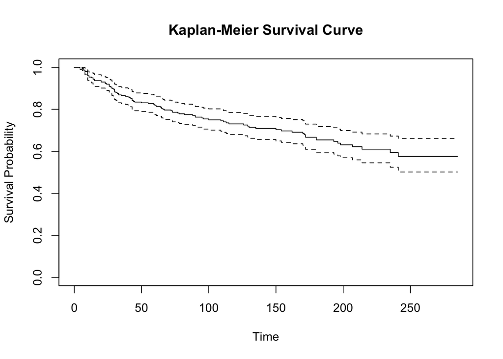

### b. Plot the cumulative hazard.

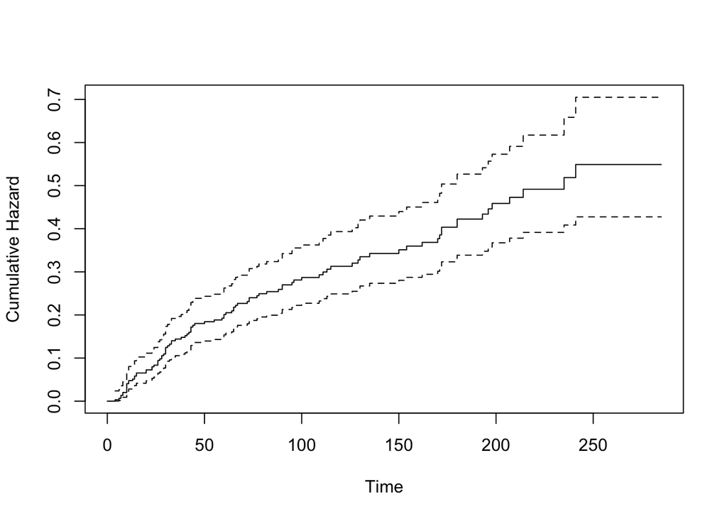

### c. Estimated survival of two groups

#### Categorical Variables

```
## Call:
## survdiff(formula = mySobject ~ data$anaemia, rho = 0)
##
##                  N Observed Expected (O-E)^2/E (O-E)^2/V
## data$anaemia=0 170       50     57.9      1.07      2.73
## data$anaemia=1 129       46     38.1      1.63      2.73
##
##  Chisq= 2.7  on 1 degrees of freedom, p= 0.1
```

```
## Call:
## survdiff(formula = mySobject ~ data$diabetes, rho = 0)
##
##                   N Observed Expected (O-E)^2/E (O-E)^2/V
## data$diabetes=0 174       56       55    0.0172    0.0405
## data$diabetes=1 125       40       41    0.0231    0.0405
##
##  Chisq= 0  on 1 degrees of freedom, p= 0.8
```

```
## Call:
## survdiff(formula = mySobject ~ data$high_blood_pressure, rho = 0)
##
##                              N Observed Expected (O-E)^2/E (O-E)^2/V
## data$high_blood_pressure=0 194       57     66.4      1.34      4.41
## data$high_blood_pressure=1 105       39     29.6      3.00      4.41
##
##  Chisq= 4.4  on 1 degrees of freedom, p= 0.04
```

```
## Call:
## survdiff(formula = mySobject ~ data$sex, rho = 0)
##
##              N Observed Expected (O-E)^2/E (O-E)^2/V
## data$sex=0 105       34     34.3   0.00254   0.00397
## data$sex=1 194       62     61.7   0.00141   0.00397
##
##  Chisq= 0  on 1 degrees of freedom, p= 0.9
```

```
## Call:
## survdiff(formula = mySobject ~ data$smoking, rho = 0)
##
##                  N Observed Expected (O-E)^2/E (O-E)^2/V
## data$smoking=0 203       66     65.8   0.00064   0.00204
## data$smoking=1  96       30     30.2   0.00139   0.00204
##
##  Chisq= 0  on 1 degrees of freedom, p= 1
```

‘anemia’, ‘smoking’, ‘sex’, and ‘diabetes’ are not statistically significant. For ‘high_blood_pressure’, we can reject null hypothesis and conclude that the survival curves are different for high blood pressure groups because the p-value = 0.04 (less than 0.05).

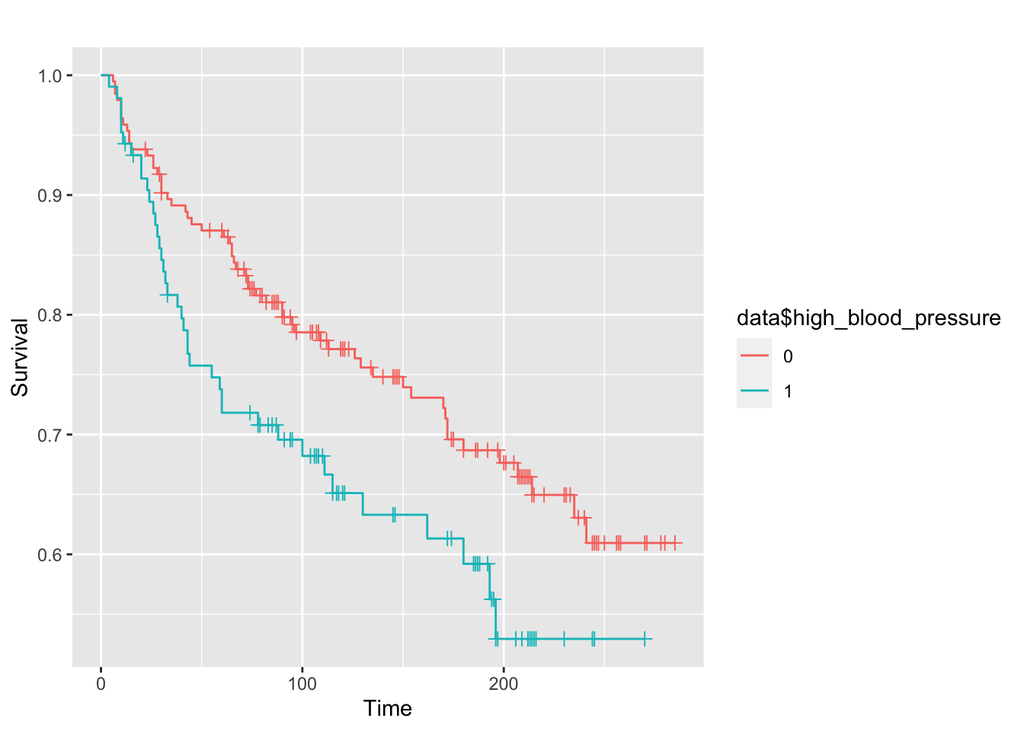

*Interpreting High Blood Pressure’s KM Plot*

High BP adds to the heart’s workload. The KM estimate curve also shows a similar trend where patients with high blood pressure (blue line) are at an increased risk of survival due to heart failure with significant lower survival probability. The survival time for individuals with high blood pressure is significantly different from individuals with normal blood pressure.

#### Continuous Variables

```
## Call:
## survdiff(formula = mySobject ~ data$age_cat, rho = 0)
##
##                       N Observed Expected (O-E)^2/E (O-E)^2/V
## data$age_cat=[40,51] 78       20     26.8     1.705     2.380
## data$age_cat=(51,60] 84       24     28.0     0.573     0.813
## data$age_cat=(60,70] 85       21     27.9     1.702     2.408
## data$age_cat=(70,95] 52       31     13.3    23.343    27.399
##
##  Chisq= 27.6  on 3 degrees of freedom, p= 4e-06
```

```
## Call:
## survdiff(formula = mySobject ~ data$serum_sodium_cat, rho = 0)
##
##                                  N Observed Expected (O-E)^2/E (O-E)^2/V
## data$serum_sodium_cat=[113,134] 83       42     25.0    11.518     15.65
## data$serum_sodium_cat=(134,137] 94       24     30.3     1.311      1.93
## data$serum_sodium_cat=(137,140] 80       19     25.9     1.838      2.53
## data$serum_sodium_cat=(140,148] 42       11     14.8     0.964      1.14
##
##  Chisq= 15.7  on 3 degrees of freedom, p= 0.001
```

```
## Call:
## survdiff(formula = mySobject ~ data$creatinine_phosphokinase_cat,
##     rho = 0)
##
##                                                   N Observed Expected (O-E)^2/E
## data$creatinine_phosphokinase_cat=[23,116]       75       19     22.7     0.593
## data$creatinine_phosphokinase_cat=(116,250]      76       28     23.2     1.000
## data$creatinine_phosphokinase_cat=(250,582]      84       32     27.8     0.631
## data$creatinine_phosphokinase_cat=(582,7.86e+03] 64       17     22.3     1.276
##                                                  (O-E)^2/V
## data$creatinine_phosphokinase_cat=[23,116]           0.780
## data$creatinine_phosphokinase_cat=(116,250]          1.325
## data$creatinine_phosphokinase_cat=(250,582]          0.892
## data$creatinine_phosphokinase_cat=(582,7.86e+03]     1.670
##
##  Chisq= 3.5  on 3 degrees of freedom, p= 0.3
```

```
## Call:
## survdiff(formula = mySobject ~ data$serum_creatinine_cat, rho = 0)
##
##                                      N Observed Expected (O-E)^2/E (O-E)^2/V
## data$serum_creatinine_cat=[0.5,0.9] 81        9     28.1    12.972    18.428
## data$serum_creatinine_cat=(0.9,1.1] 82       24     27.1     0.365     0.512
## data$serum_creatinine_cat=(1.1,1.4] 64       18     20.7     0.341     0.436
## data$serum_creatinine_cat=(1.4,9.4] 72       45     20.1    30.808    39.185
##
##  Chisq= 44.7  on 3 degrees of freedom, p= 1e-09
```

```
## Call:
## survdiff(formula = mySobject ~ data$platelets_cat, rho = 0)
##
##                                          N Observed Expected (O-E)^2/E
## data$platelets_cat=[2.51e+04,2.26e+05] 103       39     33.3     0.981
## data$platelets_cat=(2.26e+05,2.78e+05]  96       27     30.6     0.426
## data$platelets_cat=(2.78e+05,8.5e+05]  100       30     32.1     0.138
##                                        (O-E)^2/V
## data$platelets_cat=[2.51e+04,2.26e+05]     1.509
## data$platelets_cat=(2.26e+05,2.78e+05]     0.629
## data$platelets_cat=(2.78e+05,8.5e+05]      0.208
##
##  Chisq= 1.6  on 2 degrees of freedom, p= 0.5
```

```
## Call:
## survdiff(formula = mySobject ~ data$ejection_fraction_cat, rho = 0)
##
##                                           N Observed Expected (O-E)^2/E
## data$ejection_fraction_cat=EF < 30       93       51     26.8     21.93
## data$ejection_fraction_cat=30 < EF < 45 146       31     51.2      7.97
## data$ejection_fraction_cat=EF > 45       60       14     18.0      0.90
##                                         (O-E)^2/V
## data$ejection_fraction_cat=EF < 30          30.63
## data$ejection_fraction_cat=30 < EF < 45     17.32
## data$ejection_fraction_cat=EF > 45           1.12
##
##  Chisq= 31.1  on 2 degrees of freedom, p= 2e-07
```

*Interpreting Age’s KM Plot*

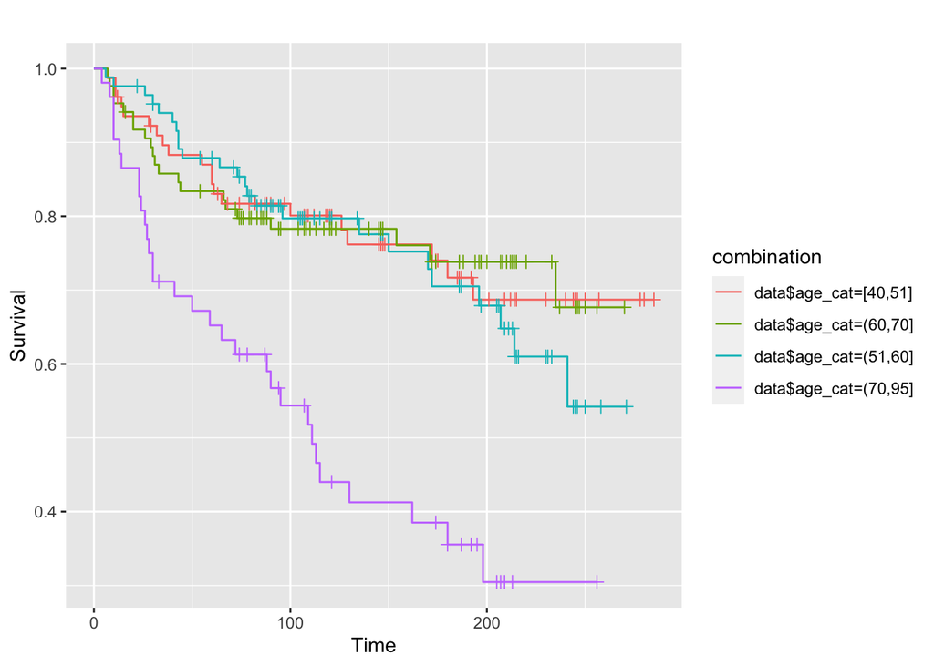

*Interpreting Ejection Fraction’s KM Plot*

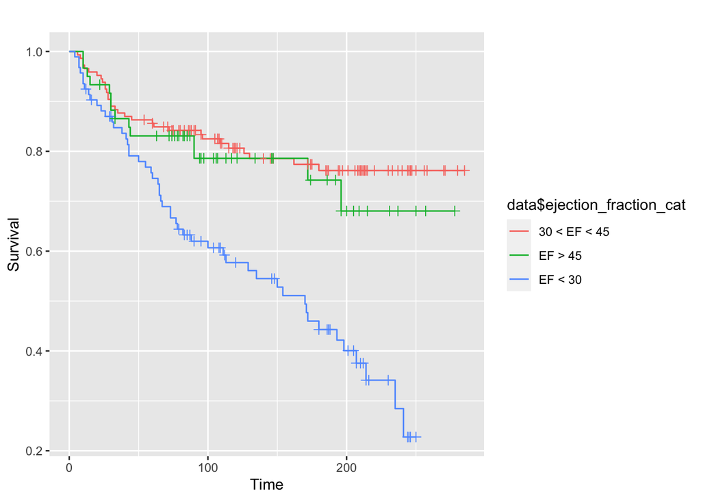

Ejection Fraction (EF) is a measurement, expressed as a percentage, of how much blood the left ventricle pumps out with each contraction. In this study, ejection fraction ranges from 14 to 80. We converted into three buckets of [0 - 30], [30 - 45], and [45, 100]. KM estimate curves shows that patients with EF less than 30 have the least chance of surviving a heart failure condition. The blue line (EF <30) shows a significant different from other group. On the other hand, the patients with EF more than 30 show a comparable and decent chance of survival.

*Interpreting Serum Creatinine’s KM Plot*

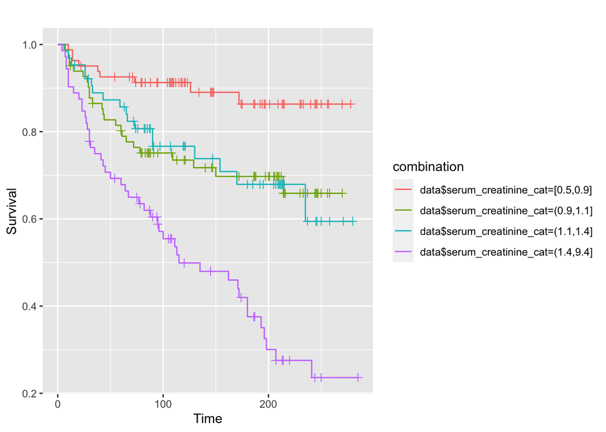

Creatinine is a chemical waste product in the blood that passes through the kidneys to be filtered and eliminated in urine, measured in mg/dL. We divided serum_creatinine into four group by quantiles: [0.5 - 0.9], [0.9 - 1.1], [1.1 - 1.4] and [1.4 - 9.4]. The plot shows that the group with highesr level of serum creatinine [1.4 to 9.4] shows the lowest survival probability (purple line), while the group with lowest level of serum creatinine [0.5 - 0.9] shows the highest survival probability (red line).The middle groups, [0.9 - 1.1] and [1.1 - 1.4] shows comparable and similar survival probability.

*Interpreting Serum Sodium’s KM Plot*

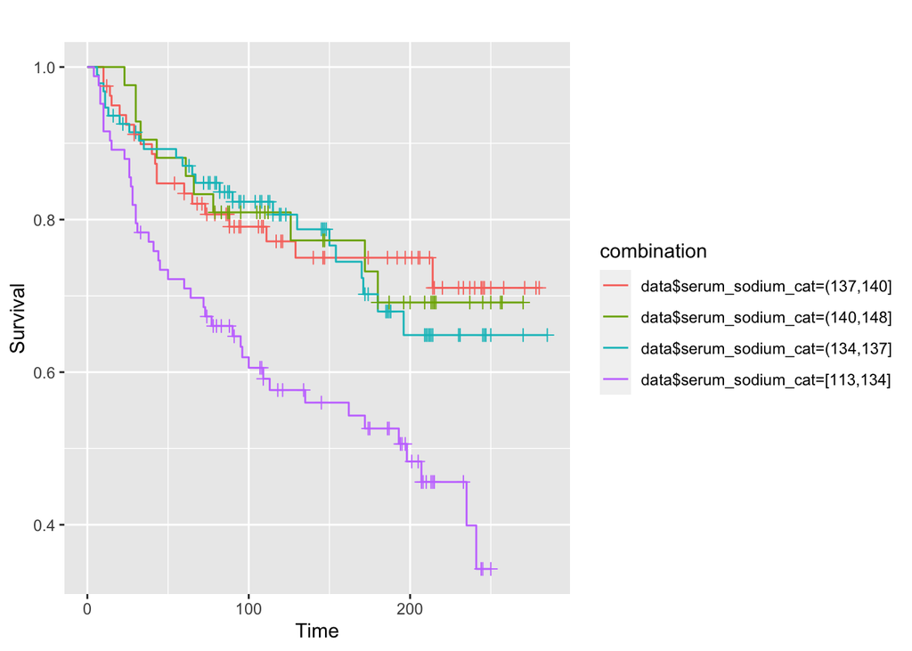

The sodium blood test measures the concentration of sodium in the blood. In this study, the range of serum sodium levels for the population ranges from [113 - 148]. To plot the KM estimates curve, we divided the population into 4 buckets - [113 - 134], [134 - 137], [137 - 140] and [140 - 148]. From the KM plots, it is observed that survival probability is least for population falling under the 1st bucket that has the lowest sodium levels [113 - 134] - purple line. The survival time for individuals in the remaining three group with sodium levels more than 134 mEq/L appears significantly different, with higher probability of survival.

### 2. Cox’s proportional hazards model

### a. Univariate Cox Regression

|  | beta | HR (95% CI for HR) | wald.test | p.value |
| --- | --- | --- | --- | --- |
| age | 0.042 | 1 (1-1.1) | 24 | 8.4e-07 |
| anaemia | 0.34 | 1.4 (0.94-2.1) | 2.7 | 0.1 |
| creatinine_phosphokinase | 0.00011 | 1 (1-1) | 1.3 | 0.26 |
| diabetes | -0.042 | 0.96 (0.64-1.4) | 0.04 | 0.84 |
| ejection_fraction | -0.046 | 0.95 (0.93-0.98) | 18 | 1.7e-05 |
| high_blood_pressure | 0.44 | 1.5 (1-2.3) | 4.3 | 0.037 |
| platelets | -7.8e-07 | 1 (1-1) | 0.53 | 0.47 |
| serum_creatinine | 0.29 | 1.3 (1.2-1.5) | 28 | 1.2e-07 |
| serum_sodium | -0.068 | 0.93 (0.9-0.97) | 12 | 0.00052 |
| sex | 0.014 | 1 (0.67-1.5) | 0 | 0.95 |

[output cut: 1 more lines]

[output not shown]

The output above shows the regression beta coefficients, the effect sizes (given as hazard ratios), 95% confidence interval, and statistical significance for each of covariate in relation to overall survival. Each factor is assessed through separate univariate Cox regressions.

The attributes ‘age’, ‘ejection_fraction’,‘high_blood_pressure’,‘serum_creatinine’, ‘serum_sodium’ have highly statistically coefficients. This result similar with what we have from the previous Kaplan Meier method.

Among all statistically significant covariates, ‘age’, ‘high_blood_pressure’,‘serum_creatinine’ have positive beta coefficients. Thus, we can interpret that older age, higher blood pressure, or higher level of creatinine in the blood is associated with poorer survival.

On the other hand, ‘ejection_fraction’ and ‘serum_sodium’ have negative beta coefficients. Thus, having higher percentage of blood leaving the heart at each contraction or having higher level of sodium in the blood is associated with better survival chance.

### b. Multivatirate Cox regression analysis

#### Model 1 with 5 factors (‘age’, ‘ejection_fraction’,‘high_blood_pressure’,‘serum_creatinine’, ‘serum_sodium’)

Now, we want to describe how the factors jointly impact on survival. To answer to this question, we’ll perform a multivariate Cox regression analysis. We’ll skip any varibles that are not significant in the univariate analysis. We’ll include the 5 factors (‘age’, ‘ejection_fraction’,‘high_blood_pressure’,‘serum_creatinine’, ‘serum_sodium’) into the multivariate model.

```
## Call:
## coxph(formula = Surv(time, DEATH_EVENT) ~ age + ejection_fraction +
##     high_blood_pressure + serum_creatinine + serum_sodium, data = data)
##
##   n= 299, number of events= 96
##
##                          coef exp(coef)  se(coef)      z Pr(>|z|)
## age                  0.044564  1.045572  0.009004  4.950 7.43e-07 ***
## ejection_fraction   -0.045759  0.955272  0.010238 -4.470 7.83e-06 ***
## high_blood_pressure  0.494319  1.639382  0.211894  2.333   0.0197 *
## serum_creatinine     0.316546  1.372380  0.070615  4.483 7.37e-06 ***
## serum_sodium        -0.037959  0.962753  0.023609 -1.608   0.1079
## ---
## Signif. codes:  0 '***' 0.001 '**' 0.01 '*' 0.05 '.' 0.1 ' ' 1
##
##                     exp(coef) exp(-coef) lower .95 upper .95
## age                    1.0456     0.9564    1.0273    1.0642
## ejection_fraction      0.9553     1.0468    0.9363    0.9746
## high_blood_pressure    1.6394     0.6100    1.0822    2.4834
## serum_creatinine       1.3724     0.7287    1.1950    1.5761
## serum_sodium           0.9628     1.0387    0.9192    1.0083
##
## Concordance= 0.729  (se = 0.028 )
## Likelihood ratio test= 73.75  on 5 df,   p=2e-14
## Wald test            = 80.07  on 5 df,   p=8e-16
## Score (logrank) test = 81.1  on 5 df,   p=5e-16
```

The p-value for all three overall tests (likelihood, Wald, and score) are significant, indicating that the model is significant. These tests evaluate the omnibus null hypothesis that all of the betas ($\beta$) are 0. In the above example, the test statistics are in close agreement, and the omnibus null hypothesis is soundly rejected.

In the multivariate Cox analysis, the covariates ‘age’, ‘ejection_fraction’,‘high_blood_pressure’ and ‘serum_creatinine’ remain significant (p-value < 0.05). However, the covariate ‘serum_sodium’ fails to be significant (p-value = 0.1079, which is grater than 0.05). Also the 95% confidence interval for HR is from 0.91 to 1.008, which includes 1, indicating ‘serum_sodium’ makes smaller contribution to the difference in HR.

*Interpreting beta in terms of hazard ratio*

The p-value for ‘age’ is 7.43e-07, with a hazard ratio HR = exp(coef) = 1.0456, indicating a strong relationship between the patients’ age and increased risk of death. The hazard ratios of covariates are interpretable as multiplicative effects on the hazard. Thus, holding other variables constant, being older increases the hazard by a factor of 1.0456. We conclude that, having older age is associated with bad prognostic.

Similar to ‘age , hazard ratios HR = exp(coef) for ’high_blood_pressure’ and ‘serum_creatinine’ are also greater than 1, indicating the increase in hazard, meaning higher blood pressure or higher level of creatinine in the blood associate with higher risk of death. These two attributes are associated with bad prognostic.

On the other hand, the p-value for ‘ejection_fraction’ is 7.83e-06, with a hazard ratio HR = 0.9553, indicating a strong relationship between the ‘ejection_fraction’ value and decreased risk of death. Holding the other covariates constant, a higher value of ‘ejection_fraction’ is associated with a better survival. This is associated with good prognostic.

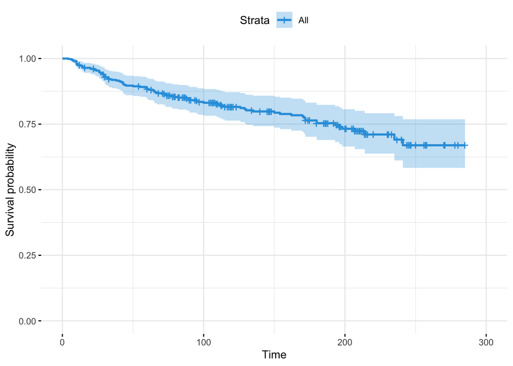

#### Model 2 with 4 factors (‘age’, ‘ejection_fraction’,‘high_blood_pressure’,‘serum_creatinine’)

```
## Call:
## coxph(formula = Surv(time, DEATH_EVENT) ~ age + ejection_fraction +
##     high_blood_pressure + serum_creatinine, data = data)
##
##   n= 299, number of events= 96
##
##                          coef exp(coef)  se(coef)      z Pr(>|z|)
## age                  0.044173  1.045163  0.009027  4.894 9.91e-07 ***
## ejection_fraction   -0.049587  0.951623  0.009968 -4.975 6.54e-07 ***
## high_blood_pressure  0.471236  1.601973  0.211410  2.229   0.0258 *
## serum_creatinine     0.347001  1.414818  0.066705  5.202 1.97e-07 ***
## ---
## Signif. codes:  0 '***' 0.001 '**' 0.01 '*' 0.05 '.' 0.1 ' ' 1
##
##                     exp(coef) exp(-coef) lower .95 upper .95
## age                    1.0452     0.9568    1.0268    1.0638
## ejection_fraction      0.9516     1.0508    0.9332    0.9704
## high_blood_pressure    1.6020     0.6242    1.0585    2.4244
## serum_creatinine       1.4148     0.7068    1.2414    1.6124
##
## Concordance= 0.729  (se = 0.029 )
## Likelihood ratio test= 71.31  on 4 df,   p=1e-14
## Wald test            = 78.79  on 4 df,   p=3e-16
## Score (logrank) test = 78.04  on 4 df,   p=5e-16
```

From the first cox regression model, we removed the insignificant variable - ‘serum_sodium’, then fit remaining four variables into the second model. In the second multivariate Cox analysis, the covariates ‘age’, ‘ejection_fraction’,‘high_blood_pressure’ and ‘serum_creatinine’ remain significant as p-value < 0.05. The p-value for all three overall tests (likelihood, Wald, and score) are significant, indicating that the model is significant.

The final Cox Proportional Hazard model with these four variables can be written as:

$h(t) = h_{0}(t) exp(\beta_{1} \ Age + \beta_{2} \ ejectrion \_fraction + \beta_{3} \ blood\_pressure + \beta_{4} \ serum\_creatinine$

- The hazard ratio for age: HR = exp(coef) = 1.0452, indicating a strong relationship between the patients’ age and increased risk of death. Holding other variables constant, an additional year of ‘age’ increases the risk of death by a factor of $e^{\beta_{1}} = 1.0452$ - that is, by 4.52%.
- Similar to ‘age , hazard ratios HR = exp(coef) = 1.602 for ’high_blood_pressure’, which is greater than 1, indicating the increase in hazard. Each increase in higher blood pressure increases the risk of death by a factor of $e^{\beta_{3}} = 1.602$ - that is, by 60.2%.
- Hazard ratios HR = exp(coef) = 1.4148 for ‘serum_creatinine’ is greater than 1, indicating the increase in hazard. The increase in serum_creatinin by one unit increases the risk of death by a factor of $e^{\beta_{4}} = 1.4148$ - that is, by 41.48%.
- Lastly, the hazard ratios HR = exp(coef) = 0.9516 for ‘ejection_fraction’ is less than 1, indicating the decrease in hazard. Thus, the increase in ejection_fraction by one unit actually lower the risk of death by a factor of $e^{\beta_{2}} = 0.9516$ - that is, by 4.84%.
- ‘age’,‘high_blood_pressure’, and ‘serum_creatinine’ are associated with bad prognostic, while ‘ejection_fraction’ is associated with good prognostic.

#### Testing Proportional Hazards Assumption with Model 2

```
##                     chisq df     p
## age                 0.271  1 0.603
## ejection_fraction   4.394  1 0.036
## high_blood_pressure 0.034  1 0.854
## serum_creatinine    1.289  1 0.256
## GLOBAL              6.304  4 0.178
```

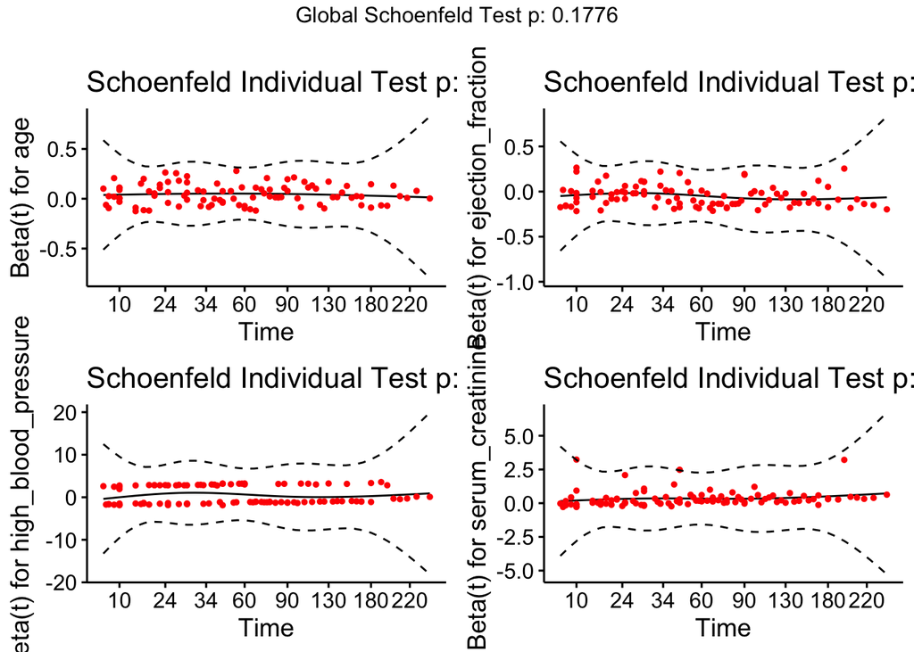

## Conclusion

With the Kaplan-Meier method, we conclude that five variables - ‘high_blodd_pressure’, ‘ejection_fraction’, ‘serum_creatinine’, ‘serum_sodium’, and age’ - each contributes significantly to the probability of death event in the study. On the other hand, under Cox Proportional Hazard Model, we fit a model with four significant varibles, including ‘high_blodd_pressure’, ‘ejection_fraction’, ‘serum_creatinine’, and ’age. From this study, we learned how different these two survival analysis methods work under the univariate and multivariate settings.

For the future, we would love to add and examine the significance of the interaction term or the power term in our Cox Proportional Hazard Model, and compare to find the best model for future prediction.